# Uso de airbags en accidentes de transito

Maria Lucia Guastoni

24/1/2021

USO DE AIRBAGS EN ACCIDENTES DE TRANSITO

# 1 Parte primera: Contexto del problema y modelo de datos

## 1.1 Introduccion

El presente trabajo intenta analizar la influencia de los airbags en la tasa de fatalidad de los accidentes de transito. Para ello, ademas de informacion relativa a la presencia o no de airbags en los coches, se incorporan variables de control tales como el uso de cinturon de seguridad, el tipo de impacto, la velocidad del impacto, entre otras, con el objeto de identificar otras variables que puedan afectar la tasa de fatalidad.

El dataset contiene 26.217 observaciones de accidentes automovilísticos denunciados por la policía, ocurridos en EEUU entre los años 1997 a 2002, en los que hay un evento que causa algún daño (a personas o propiedad) y de los cuales se remolcó al menos un vehículo. Los datos están restringidos a los ocupantes de los asientos delanteros. Las variables incluidas son las siguientes:

1 - dvcat: velocidad estimada del impacto (v. categórica ordinal con cinco niveles)

2 - dead: murió / no murió (v. binaria)

3 - airbag: el coche tiene airbag / no tiene airbag (v. binaria)

4 - seatbelt: el coche tiene cinturón de seguridad / no tiene cinturón de seguridad (v. binaria)

5 - frontal: choque frontal / no frontal (v. binaria)

6 - sex: F / M (v. binaria)

7 - ageOFocc: edad del ocupante en años (v. númerica)

8 - yearacc: año del accidente (fecha)

9 - yearVeh: año del modelo del vehículo (fecha)

10 - abcat: ¿Se desplegaron uno o más airbag (del conductor o del pasajero)? Se desplegó / no se desplegó (v. binaria)/ no tiene airbag

11 - occRole: conductor / pasajero (v. binaria)

12 - injSeverity: gravedad de la lesión (v. categórica con seis niveles):

```
0: no ha sufrido lesiones,

1: posible lesión,

2: no ha sufrido ninguna incapacidad,

3: ha sufrido una incapacidad,

4: se ha matado en el accidente,

5: desconocido,

6: muerte previa a la llegada al hospital
```

El trabajo esta estructurado en tres partes.

La primera consiste en contextualizar el problema y explicar los datos.

En la segunda parte se realiza una analisis exploratorio de los datos, distinguiendo por tipo de dato, asi como un analisis cruzado de ciertas variables de interes para el presente trabajo.

Finalmente, en la tercera parte, se aplican cinco tecnicas distintas de Machine Learning y se evalua su performance.

## 1.2 Carga de datos y vista preliminar

```r
data <- read.csv("../data/nassCDS.csv")
df <- as_tibble(data)
head(df)
```

```
# A tibble: 6 x 16
      X dvcat weight dead  airbag seatbelt frontal sex   ageOFocc yearacc
  <int> <chr>  <dbl> <chr> <chr>  <chr>      <int> <chr>    <int>   <int>
1     1 25-39   25.1 alive none   belted         1 f           26    1997
2     2 10-24   25.1 alive airbag belted         1 f           72    1997
3     3 10-24   32.4 alive none   none           1 f           69    1997
4     4 25-39  495.  alive airbag belted         1 f           53    1997
5     5 25-39   25.1 alive none   belted         1 f           32    1997
6     6 40-54   25.1 alive none   belted         1 f           22    1997
# ... with 6 more variables: yearVeh <int>, abcat <chr>, occRole <chr>,
#   deploy <int>, injSeverity <int>, caseid <chr>
```

```r
str(df)
```

```
tibble [26,217 x 16] (S3: tbl_df/tbl/data.frame)
 $ X          : int [1:26217] 1 2 3 4 5 6 7 8 9 10 ...
 $ dvcat      : chr [1:26217] "25-39" "10-24" "10-24" "25-39" ...
 $ weight     : num [1:26217] 25.1 25.1 32.4 495.4 25.1 ...
 $ dead       : chr [1:26217] "alive" "alive" "alive" "alive" ...
 $ airbag     : chr [1:26217] "none" "airbag" "none" "airbag" ...
 $ seatbelt   : chr [1:26217] "belted" "belted" "none" "belted" ...
 $ frontal    : int [1:26217] 1 1 1 1 1 1 1 1 0 1 ...
 $ sex        : chr [1:26217] "f" "f" "f" "f" ...
 $ ageOFocc   : int [1:26217] 26 72 69 53 32 22 22 32 40 18 ...
 $ yearacc    : int [1:26217] 1997 1997 1997 1997 1997 1997 1997 1997 1997 1997 ...
 $ yearVeh    : int [1:26217] 1990 1995 1988 1995 1988 1985 1984 1987 1984 1987 ...
 $ abcat      : chr [1:26217] "unavail" "deploy" "unavail" "deploy" ...
 $ occRole    : chr [1:26217] "driver" "driver" "driver" "driver" ...
 $ deploy     : int [1:26217] 0 1 0 1 0 0 0 0 0 0 ...
 $ injSeverity: int [1:26217] 3 1 4 1 3 3 3 4 1 0 ...
 $ caseid     : chr [1:26217] "2:3:1" "2:3:2" "2:5:1" "2:10:1" ...
```

Se comienza a explorar los datos. A primera vista pueden identificarse features que no aportan informacion alguna, por lo tanto se procede a eliminarlas:

```r
df <- dplyr::select(df, -X, -weight, -deploy)
```

La variable `deploy` se elimina puesto que la informacion que brinda es exactamente la misma que `airbag_deployed`. La variable `weight` son las ponderaciones de las observaciones, dado que la informacion ha sido extraida de un muestreo por etapas.

A continuacion, resulta util observar los valores unicos que tiene cada una de las variables, asi como su cantidad:

```r
df %>% dplyr::select(-caseid) %>%
  lapply(unique)
```

```
$dvcat
[1] "25-39"   "10-24"   "40-54"   "55+"     "1-9km/h"

$dead
[1] "alive" "dead"

$airbag
[1] "none"   "airbag"

$seatbelt
[1] "belted" "none"

$frontal
[1] 1 0

$sex
[1] "f" "m"

$ageOFocc
 [1] 26 72 69 53 32 22 40 18 21 67 54 37 71 63 23 33 17 20 45 36 19 41 30 16 52
[26] 64 76 25 24 39 27 74 78 55 43 44 62 82 65 42 46 81 50 66 75 57 77 61 38 31
[51] 58 29 51 28 59 49 35 70 56 84 87 68 60 79 73 86 47 85 83 80 34 48 91 95 93
[76] 88 89 97 94 96 92 90

$yearacc
[1] 1997 1998 1999 2000 2001 2002

$yearVeh
 [1] 1990 1995 1988 1985 1984 1987 1982 1991 1994 1986 1989 1992 1993 1977 1968
[16] 1996 1983 1997 1981 1979 1974 1998 1973   NA 1976 1980 1975 1978 1971 1972
[31] 1966 1969 1970 1963 1959 1967 1999 2000 1965 1964 2001 2002 1956 1961 2003
[46] 1953

$abcat
[1] "unavail"  "deploy"   "nodeploy"

$occRole
[1] "driver" "pass"

$injSeverity
[1]  3  1  4  0  2  5 NA  6
```

## 1.3 Limpieza de datos

### 1.3.1 Valores faltantes

Puede observarse que las unicas variables que tienen valores faltantes son `yearVeh` e `injSeverity`. Se procede a investigar un poco mas:

```r
colSums(is.na(df))
```

```
      dvcat        dead      airbag    seatbelt     frontal         sex
          0           0           0           0           0           0
   ageOFocc     yearacc     yearVeh       abcat     occRole injSeverity
          0           0           1           0           0         153
     caseid
          0
```

```r
df[rowSums(is.na(df)) > 0,]
```

```
# A tibble: 154 x 13
   dvcat dead  airbag seatbelt frontal sex   ageOFocc yearacc yearVeh abcat
   <chr> <chr> <chr>  <chr>      <int> <chr>    <int>   <int>   <int> <chr>
 1 10-24 alive none   belted         0 f           36    1997    1984 unav~
 2 25-39 alive none   none           1 m           22    1997    1993 unav~
 3 10-24 alive airbag belted         1 m           27    1997      NA depl~
 4 10-24 alive none   belted         0 f           80    1997    1981 unav~
 5 10-24 alive none   belted         0 f           27    1997    1984 unav~
 6 10-24 alive airbag belted         1 m           23    1997    1995 depl~
 7 10-24 alive none   none           1 m           25    1997    1989 unav~
 8 25-39 alive none   belted         1 m           40    1997    1993 unav~
 9 25-39 alive none   belted         1 m           32    1997    1988 unav~
10 25-39 alive airbag none           1 f           27    1997    1993 depl~
# ... with 144 more rows, and 3 more variables: occRole <chr>,
#   injSeverity <int>, caseid <chr>
```

Puede verse que todos los NA se encuentran en la columna `injSeverity`, excepto uno, que pertenece a la variable `yearVeh`. En total son 154 filas con NA, lo cual representa, sobre el total de filas del dataset, un 0.58%, es decir, menos del 1% de las observaciones. Por lo tanto, una posibilidad es simplemente eliminar estas observaciones.

Otra alternativa es reemplazar los valores faltantes por la moda de la variable. Sin embargo, al tratarse de tan pocas observaciones, y con el objetivo de no alterar los datos, se prefiere eliminar las observaciones en cuestion:

```r
df <- drop_na(df)
```

## 1.4 Formato de los datos

A continuacion se asigna a cada variable el formato que corresponde segun el tipo de datos que contiene.

Existe una variable, `dvcat`, que es un factor ordenado, lo cual quiere decir que esta compuesta por una estructura de 5 categorias ordenadas. Tambien hay una variable categorica que es un factor con 6 niveles, `injSeverity`.

Por otro lado, tenemos siete variables que son variables dummy o binarias, lo cual indica que pueden tomar solo dos valores, y por lo tanto las transformaremos a factor. Dichas variables son: “dead”, “airbag”, “seatbelt”, “frontal”, “sex”, “occRole”, “abcat”.

Existen dos features que son fechas - `yearacc`, `yearVeh` -, mas precisamente años, y por tanto seran convertidas al formato correspondiente, con ayuda de la libreria `lubridate`.

Finalmente, contamos en este dataset con una sola variable numerica, la cual será casteada a entero.

```r
# Primero genero una lista para cada tipo de dato, excepto para la unica variable numerica y para las dos variables de fecha
factor_ordenado <- c("dvcat")
fact <- c("dead", "airbag", "seatbelt", "frontal", "sex", "occRole", "abcat", "injSeverity")
fechas <- c("yearacc", "yearVeh")

# Luego, casteamos:
# factor ordenado:
df[factor_ordenado] <- lapply(df[factor_ordenado], as.ordered)
# factor:
df[fact] <- lapply(df[fact], as.factor)
# fechas:
df$yearacc <- as.Date(as.character(df$yearacc), format = "%Y")
df$yearacc <- year(df$yearacc)
df$yearVeh <- as.Date(as.character(df$yearVeh), format = "%Y")
df$yearVeh <- year(df$yearVeh)
# integer:
df$ageOFocc <- as.integer(df$ageOFocc)
```

Ahora que las variables tienen el formato adecuado, se pueden estimar los prinicpales estadisticos de resumen de cada una de ellas:

```r
summary(df)
```

```
     dvcat          dead          airbag        seatbelt     frontal
 1-9km/h:  676   alive:24883   airbag:14336   belted:18465   0: 9288
 10-24  :12766   dead : 1180   none  :11727   none  : 7598   1:16775
 25-39  : 8165
 40-54  : 2965
 55+    : 1491


 sex          ageOFocc        yearacc        yearVeh          abcat
 f:12178   Min.   :16.00   Min.   :1997   Min.   :1953   deploy  : 8799
 m:13885   1st Qu.:22.00   1st Qu.:1998   1st Qu.:1989   nodeploy: 5537
           Median :33.00   Median :2000   Median :1994   unavail :11727
           Mean   :37.22   Mean   :2000   Mean   :1993
           3rd Qu.:48.00   3rd Qu.:2001   3rd Qu.:1997
           Max.   :97.00   Max.   :2002   Max.   :2003

   occRole      injSeverity    caseid
 driver:20541   0:6478      Length:26063
 pass  : 5522   1:5595      Class :character
                2:4242      Mode  :character
                3:8495
                4:1118
                5: 133
                6:   2
```

Puede verificarse que ninguna de las variables contiene valores extremos o outliers.

## 1.5 Verificacion de inconsistencias

### 1.5.1 `abcat`

Es necesario hacer una observacion respecto a la variable `abcat`. Como ya se ha mencionado, esta indica si el airbag se desplego o no en el momento del accidente. Dado el analisis que se desea realizar en el presente trabajo, lo que interesa es distinguir el efecto de la presencia o no del airbag. Por tanto, no interesa particularmente si el airbag no se desplego o si el coche no tenia airbag, lo importante es considerar si el airbag intervino en el momento del accidente o no, independientemente del motivo. Por tanto, se hara una modificacion a esta variable: se unificaran las categorias `nodeploy` y `unavail` de `abcat`. El objetivo es simplificar y lograr un analisis mas relevante y preciso de los casos.

```r
levels(df$abcat) <- c("deployed", "nodeploy/unavail", "nodeploy/unavail")
```

### 1.5.2 `caseid`

En primer lugar, es necesario analizar el valor de `caseid`. Esta variable representa la identificación de cada vehiculo en un año dado. Ha sido creada combinando la unidad de muestreo de poblaciones, el numero de caso y el numero de vehiculo. Es decir, dentro de cada año de accidente, sirve para identificar de forma única el vehículo.

```r
n_distinct(df$caseid)
```

```
[1] 9400
```

```r
df %>% group_by(caseid) %>%
  dplyr::summarise(casos_por_id = n())
```

```
# A tibble: 9,400 x 2
   caseid   casos_por_id
   <chr>           <int>
 1 11:1:1              3
 2 11:1:2              4
 3 11:10:1             3
 4 11:10:2             2
 5 11:100:2            2
 6 11:101:1            1
 7 11:102:1            4
 8 11:102:2            1
 9 11:103:1            6
10 11:103:2            4
# ... with 9,390 more rows
```

```r
filter(df, caseid == "11:103:1")
```

```
# A tibble: 6 x 13
  dvcat dead  airbag seatbelt frontal sex   ageOFocc yearacc yearVeh abcat
  <ord> <fct> <fct>  <fct>    <fct>   <fct>    <int>   <dbl>   <dbl> <fct>
1 10-24 alive airbag belted   1       m           48    1997    1997 depl~
2 1-9k~ alive none   belted   0       m           55    1998    1995 node~
3 10-24 alive airbag none     1       f           19    2000    1994 depl~
4 10-24 alive none   none     1       f           18    2000    1994 node~
5 10-24 alive airbag belted   1       m           29    2001    2000 depl~
6 40-54 alive none   none     1       f           47    2002    1986 node~
# ... with 3 more variables: occRole <fct>, injSeverity <fct>, caseid <chr>
```

Por ejemplo, en el caso de `caseid` = 11:103:1, se observa que existen 6 observaciones con ese id, que corresponden a 5 años distintos. En el año 2000 existen dos observaciones con el mismo id: mirando la columna `occRole` se entiende que en el mismo vehiculo viajaban dos personas, y por ello el `caseid` dentro del mismo año es identico.

Para mayor claridad, se modificará el id, de modo que exista un id para cada persona de cada vehiculo, independientemente del año en que ocurrio el accidente. Se sabe que los datos estan restringidos a los ocupantes de los asientos delanteros, con lo cual, como maximo, deberia haber dos observaciones por vehiculo.

El nuevo “caseid” vendra determinado de la siguiente manera:

1. año del accidente: se obtiene de la columna `yearacc`
2. año del vehiculo: se obtiene de la columna `yearVeh`
3. unidad de muestreo: es el primer numero que aparece en `caseid`
4. numero de caso: es el segundo numero que aparece en `caseid`
5. indicador de conductor o pasajero: se obtiene de la columna `occRole`.

```r
# 3 y 4. unidad de muestreo y numero de caso: para ellos separamos por los ":" la columna "caseid":
df <- df %>%
  separate(caseid, into=c("unidad_muestreo", "caso", "nro_vehiculo"), sep=":", remove = F)


# 5. indicador de conductor o pasajero
df$occRole = factor(df$occRole,
                levels = c("driver", "pass" ),
                labels = c(0,1))

# Se juntan los cinco valores para generar el nuevo caseid de cada persona:
df$case_id_persona <- paste(df$yearacc, df$yearVeh, df$unidad_muestreo, df$caso, df$occRole, sep = ":")
```

A continuacion se controla que no haya ids duplicados, puesto que cada observacion debe corresponder a un individuo:

```r
# se calcula el numero de ids distintos:
n_distinct(df$case_id_persona)
```

```
[1] 25611
```

```r
#se filtra cuales son los ids duplicados
df %>% group_by(case_id_persona) %>%
 dplyr::summarise(casos_por_id = n()) %>%
  filter(casos_por_id != 1)
```

```
# A tibble: 451 x 2
   case_id_persona    casos_por_id
   <chr>                     <int>
 1 1997:1984:2:151:0             2
 2 1997:1984:43:230:0            2
 3 1997:1984:45:20:0             2
 4 1997:1984:45:20:1             2
 5 1997:1984:8:19:0              2
 6 1997:1985:75:127:0            2
 7 1997:1986:12:76:0             2
 8 1997:1986:48:59:0             2
 9 1997:1987:11:105:0            2
10 1997:1987:12:102:0            2
# ... with 441 more rows
```

```r
#se filtra una fila del dataset para obtener mayor informacion:
filter(df, case_id_persona == "1997:1984:2:151:0")
```

```
# A tibble: 2 x 17
  dvcat dead  airbag seatbelt frontal sex   ageOFocc yearacc yearVeh abcat
  <ord> <fct> <fct>  <fct>    <fct>   <fct>    <int>   <dbl>   <dbl> <fct>
1 25-39 alive none   belted   0       m           23    1997    1984 node~
2 25-39 alive none   belted   1       m           46    1997    1984 node~
# ... with 7 more variables: occRole <fct>, injSeverity <fct>, caseid <chr>,
#   unidad_muestreo <chr>, caso <chr>, nro_vehiculo <chr>,
#   case_id_persona <chr>
```

Al obtener la cantidad de valores unicos, se observa que son menos que la cantidad de observaciones del dataset: 25611 versus 26063: existen 451 ids duplicados. Profundizando en el analisis de la composicion del “caseid”, se concluye que al mismo se le debería agregar `yearacc` y `yearVeh`, ademas de `occRol` (para identificar a los individuos):

```r
df$case_id_persona2 <- paste(df$caseid, df$yearacc, df$yearVeh, df$occRole, sep = ":")
```

Se controla la cantidad de ids unicos de personas:

```r
n_distinct(df$case_id_persona2)
```

```
[1] 26063
```

Y se comprueba que efectivamente existe un id para cada persona o individuo comprendido en el dataset. Luego nos interesa tener tambien un id por vehiculo, para lo cual solo añadimos a `caseid`, `yearacc` y `yearVeh`:

```r
df$case_id_vehiculo <- paste(df$caseid, df$yearacc, df$yearVeh, sep = ":")
```

Se comprueba que `case_id_vehiculo` sea correcto:

```r
# cantidad de ids unicos en el dataset:
n_distinct(df$case_id_vehiculo)
```

```
[1] 20622
```

```r
nro_vehiculos <- df %>% group_by(case_id_vehiculo) %>%
  dplyr::summarise(casos_por_id = n())

nrow(nro_vehiculos)
```

```
[1] 20622
```

```r
length(which(nro_vehiculos$casos_por_id > 2))
```

```
[1] 0
```

```r
length(which(nro_vehiculos$casos_por_id == 2))*2 +
length(which(nro_vehiculos$casos_por_id == 1))
```

```
[1] 26063
```

### 1.5.3 `yearacc` vs `yearVeh`

Otro tipo de inconsistencia que se desea descartar es una que tiene que ver con fechas: el año del accidente debe ser, en todos los casos, mayor al año del vehiculo, puesto que no resulta logico que el accidente ocurra antes de que el vehiculo salga a la venta:

```r
inconsistencia <- filter(df, yearacc < yearVeh)
inconsistencia$yearVeh - inconsistencia$yearacc
```

```
  [1] 1 1 1 1 1 1 1 1 1 1 1 1 1 1 1 1 1 1 1 1 1 1 1 1 1 1 1 1 1 1 1 1 1 1 1 1 1
 [38] 1 1 1 1 1 1 1 1 1 1 1 1 1 1 1 1 1 1 1 1 1 1 1 1 1 1 1 1 1 1 1 1 1 1 1 1 1
 [75] 1 1 1 1 1 1 1 1 1 1 1 1 1 1 1 1 1 1 1 1 1 1 1 1 1 1 1 1 1 1 1 1 1 1 1 1 1
[112] 1 1 1 1 1 1 1 1 1 1 1 1 1 1 1 1 1 1 1 1 1 1 1 1 1 1 1 1 1 1 1 1 1 1 1 1 1
[149] 1 1 1 1 1
```

Se han encontrado 153 casos en los que el año del modelo del vehiculo es superior al año del accidente, y en todos los casos la diferencia es de un año. Dado que esto no tiene sentido, se eliminan estos casos

```r
df <- filter(df, yearacc >= yearVeh)
```

### 1.5.4 `dead` vs `injSeverity`

Estas dos variables estan relacionadas entre si, puesto que uno de los niveles de la variable `injSeverity` indica si la persona ha muerto a causa del accidente o no. Cabe en esta instancia recordar el significado de cada uno de los niveles de `injSeverity`:

0: no ha sufrido lesiones, 1: posible lesion, 2: no ha sufrido ninguna incapacidad, 3: ha sufrido una incapacidad, 4: se ha matado en el accidente, 5: desconocido, 6: muerte previa a la llegada al hospital

Por lo tanto, es necesario que estas dos variables coincidan. La frecuencia absoluta de cada variable es:

```r
table(df$dead)
```

```
alive  dead
24741  1169
```

```r
table(df$injSeverity)
```

```
   0    1    2    3    4    5    6
6437 5557 4216 8458 1107  133    2
```

Dado que el nivel 6 posee solo 2 observaciones, se agrupara junto con el nivel 4:

```r
levels(df$injSeverity) <- c("0", "1", "2", "3", "4", "5", "4")
levels(df$injSeverity)
```

```
[1] "0" "1" "2" "3" "4" "5"
```

Con lo cual, ahora se tiene:

```r
table(df$dead)
```

```
alive  dead
24741  1169
```

```r
table(df$injSeverity)
```

```
   0    1    2    3    4    5
6437 5557 4216 8458 1109  133
```

Donde puede observarse que la cantidad de muertes difiere entre ambas variables: en la columna `dead` se registran 60 muertes mas que en `injSeverity`.

Se filtan las observaciones que se registran como “dead” en esta columna, mientras que en `injSeverity` no figuran como tal:

```r
df_d <- filter(df, dead == "dead" & injSeverity != 4)
nrow(df_d)
```

```
[1] 96
```

```r
unique(df_d$injSeverity)
```

```
[1] 3 5 2 1
Levels: 0 1 2 3 4 5
```

Se encuentra que son 96 casos. Tambien se puede ver que en estos casos, el valor de `injSeverity` es 1,2,3 o 5, por lo tanto, no se identifica ninguna tendencia o patron que pueda ayudar a entender estas inconsistencias.

Del otro lado, se filtran los casos que se registran como muerte en la columna `injSeverity` y que no se corresponden en la columna `dead`.

```r
df_is <- filter(df, dead != "dead" & injSeverity == 4)
nrow(df_is)
```

```
[1] 36
```

Se trata de 36 casos. La diferencia entre los 96 y 36 casos encontrados, arroja la diferencia de 60 que se encontro al principio de este analisis.

Dada esta inconsistencia encontrada, y puesto que no es posible resolverla, se procede a eliminar los 132 casos (96+36):

```r
df <- anti_join(df, df_d)
df <- anti_join(df, df_is)

# se comprueba que ahora la cantidad de muertes sea la misma:

table(df$dead)
```

```
alive  dead
24705  1073
```

```r
table(df$injSeverity)
```

```
   0    1    2    3    4    5
6437 5556 4209 8371 1073  132
```

## 1.6 Puesta a punto de los datos

Antes de concluir con esta primera parte, se eliminaran las variables que no aportan informacion y se cambia el nombre de algunas variables para mayor claridad, y para dejar los datos limpios para la siguiente etapa:

```r
df <- dplyr::select(df, -nro_vehiculo, -unidad_muestreo, -case_id_persona, -caso)
#-caseid,
df <- dplyr::rename(df, speed_impact = dvcat, airbag_deployed = abcat, case_id_persona = case_id_persona2, female = sex)
```

```r
#write.csv(df, "datos_limpios.csv", row.names = FALSE, quote = TRUE)
```

# 2 Parte segunda: Exploratory Data Analysis

## 2.1 Estadistica descriptiva de datos cualitativos

Se comienza analizando las variables cualitativas: `dead`, `airbag`,`seatbelt`, `frontal`, `female`, `occRole`, `airbag_deployed` e `infSeverity`.

Para ello, se filtran dichas variables y se genera un nuevo dataframe:

```r
df_fact <- dplyr::select(df, "dead", "airbag", "seatbelt", "frontal", "female", "occRole", "airbag_deployed", "injSeverity")
```

Como primer paso, se calcula la frecuencia relativa de las categorias de cada variable:

```r
df_fact %>%
   lapply(table) %>%
   lapply(prop.table)
```

```
$dead

     alive       dead
0.95837536 0.04162464

$airbag

   airbag      none
0.5477539 0.4522461

$seatbelt

   belted      none
0.7094422 0.2905578

$frontal

        0         1
0.3561952 0.6438048

$female

        f         m
0.4682675 0.5317325

$occRole

       0        1
0.788657 0.211343

$airbag_deployed

        deployed nodeploy/unavail
       0.3357902        0.6642098

$injSeverity

          0           1           2           3           4           5
0.249709054 0.215532625 0.163278765 0.324734270 0.041624641 0.005120646
```

Las variables `airbag` y `airbag_deployed` indican la cantidad de coches que tienen airbag: casi 55% de los coches tienen airbag, y de estos, en el 61% (osea, el 33,6% del total de la muestra) de los casos el airbag se ha activado, mientras que en el 39% (21,2% del total de la muestra) de los casos el airbag no se desplego. Un 45% del total de los coches de la muestra no posee airbag.

En cuanto al cinturon de seguridad, en el 70% de los casos las personas que viajaban en el coche lo tenian puesto, versus un 30% que no.

El 79% de los individuos de la muestra son conductores, y un 21% acompañantes o pasajeros. Ademas, el 47% de los individuos de la muestra son mujeres y el 53% varones.

### 2.1.1 `airbag_deployed` y `dead`

Resulta interesante analizar algunas variables de forma conjunta. En primer lugar, se analizara la relacion entre `dead` y `airbag_deployed`, justamente para observar la cantidad de muertes cuando hay airbag y cuando no:

```r
CrossTable(df$dead, df$airbag_deployed, prop.chisq = FALSE)
```

```
   Cell Contents
|-------------------------|
|                       N |
|           N / Row Total |
|           N / Col Total |
|         N / Table Total |
|-------------------------|


Total Observations in Table:  25778


             | df$airbag_deployed
     df$dead |         deployed | nodeploy/unavail |        Row Total |
-------------|------------------|------------------|------------------|
       alive |             8336 |            16369 |            24705 |
             |            0.337 |            0.663 |            0.958 |
             |            0.963 |            0.956 |                  |
             |            0.323 |            0.635 |                  |
-------------|------------------|------------------|------------------|
        dead |              320 |              753 |             1073 |
             |            0.298 |            0.702 |            0.042 |
             |            0.037 |            0.044 |                  |
             |            0.012 |            0.029 |                  |
-------------|------------------|------------------|------------------|
Column Total |             8656 |            17122 |            25778 |
             |            0.336 |            0.664 |                  |
-------------|------------------|------------------|------------------|
```

Graficamente:

[figure not shown]

```r
ggplot(data = df_fact) +
   geom_mosaic(aes(x = product(dead,airbag_deployed), fill=dead)) +
   labs(y = "sobrevivio / no sobrevivio",
        x = "airbag",
        title="Sobrevivientes en funcion del uso de airbag") +
  theme(plot.title = element_text(size=10, hjust = 0.5),
  axis.text.x = element_text(size=8),
  axis.title = element_text(size = 8)) +
  annotate(geom="text",x=0.43,y=-0.02,label="sin airbag                                 con airbag", color="black",size=3)
```

### 2.1.2 `airbag_deployed`, `dead` y `seatbelt`

La proxima tabla incluye la variable `seatbelt`. El objetivo es ver como influye el tener o no el cinturon de seguridad al momento del impacto.

```r
prop.table(table(df$dead, df$seatbelt, df$airbag_deployed), margin = c(2,3))
```

```
, ,  = deployed


            belted       none
  alive 0.97992898 0.91280404
  dead  0.02007102 0.08719596

, ,  = nodeploy/unavail


            belted       none
  alive 0.97299128 0.91828281
  dead  0.02700872 0.08171719
```

### 2.1.3 `airbag_deployed` e `injSeverity`

A continuacion se analiza la relacion entre el nivel de severidad del accidente y la presencia o no de airbag.

Cabe en esta instancia recordar el significado de cada uno de los niveles de `injSeverity`:

0: no ha sufrido lesiones,

1: posible lesion,

2: no ha sufrido ninguna incapacidad,

3: ha sufrido una incapacidad,

4: se ha matado en el accidente,

5: desconocido,

6: muerte previa a la llegada al hospital

La tabla de frecuencias absolutas y relativas expresada en porcentaje para esta variable se muestra a continuacion:

```r
table(df$injSeverity)
```

```
   0    1    2    3    4    5
6437 5556 4209 8371 1073  132
```

```r
round((prop.table(table(df$injSeverity)))*100,2)
```

```
    0     1     2     3     4     5
24.97 21.55 16.33 32.47  4.16  0.51
```

Puede verse que la mayor frecuencia se encuentra en el nivel 3: el 32,47% de las personas de la muestra ha sufrido una incapacidad luego del accidente.

Ahora, se realiza un analisis conjunto de las dos variables:

```r
round(prop.table(table(df$airbag_deployed, df$injSeverity), margin = 1)*100,3)
```

```
                        0      1      2      3      4      5
  deployed         19.177 22.458 19.998 34.150  3.697  0.520
  nodeploy/unavail 27.900 21.096 14.473 31.626  4.398  0.508
```

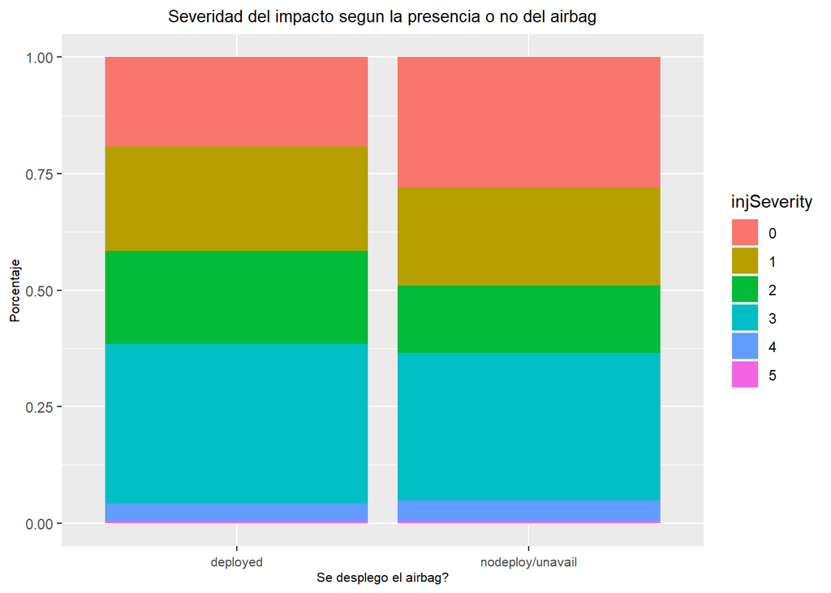

```r
ggplot(data=df) +
  geom_bar(mapping = aes(x= airbag_deployed, fill =injSeverity),
          position = "fill") +
          labs(title = "Severidad del impacto segun la presencia o no del airbag") +
          xlab("Se desplego el airbag?") +
          ylab("Porcentaje") +
          theme(plot.title = element_text(size = 10, hjust = 0.5),
                axis.text.x = element_text(size = 8, vjust = 0.5),
                axis.title = element_text(size = 8))
```

El analisis respecto a la variable `airbag_deployed` indica que en los niveles 1, 2 y 3 de `injSeverity`, hay una mayor cantidad de casos cuando el airbag se desplego en comparacion con la ausencia de airbag (`injSeverity` = 5 es unknown, por esto no es tomado en cuenta en el analisis).

Lo contrario ocurre en los niveles 0 y 4 de `injSeverity`, que resultan ser ademas los “casos extremos”: 0 señala que no hubo lesiones y 4 indica que la persona murio. Es decir, cuando el airbag no se desplego, hubo mayor cantidad de personas (en terminos relativos) que no sufrieron lesiones y tambien hubo mayor cantidad de muertes con respecto a los casos en que el airbag se desplego. Quizas esto indica que el airbag es mas util en accidentes de transito mas severos, y que cuando el accidente es menor el airbag no es de ayuda.

## 2.2 Estadistica descriptiva de datos ordinales

### 2.2.1 `speed_impact`

El dataset contiene una unica variable ordinal: `speed_impact`, la cual indica el rango de velocidad a la que ocurrio el impacto, y tiene cinco categorias distintas:

```r
levels(df$speed_impact)
```

```
[1] "1-9km/h" "10-24"   "25-39"   "40-54"   "55+"
```

La frecuencia relativa de ocurrencia de cada categoria es la siguiente:

```r
df %>% dplyr::select(speed_impact) %>%
  table() %>%
  prop.table()%>%
  round(3)
```

```
.
1-9km/h   10-24   25-39   40-54     55+
  0.026   0.491   0.313   0.113   0.056
```

Analizando la frecuencia relativa de ocurrencia de accidentes segun la velocidad a la que ocurrio el impacto, se observa que la mayor cantidad de impactos ocurren a una velocidad de entre 10 y 24 km por hora.

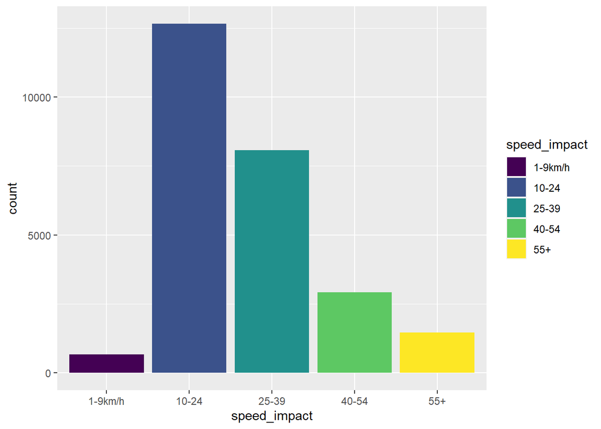

```r
ggplot(data = df) +
  geom_bar(mapping = aes(x = speed_impact, fill = speed_impact))
```

## 2.3 Estadistica descriptiva de datos cuantitativos

### 2.3.1 `ageOFocc`

La unica variable cuantitativa del dataset es `ageOFocc`, la cual indica la edad, en años cumplidos, de las personas que viajaban en el coche en el momento del accidente. Como se ha visto, la edad minima de la muestra es de 16, y la maxima 97.

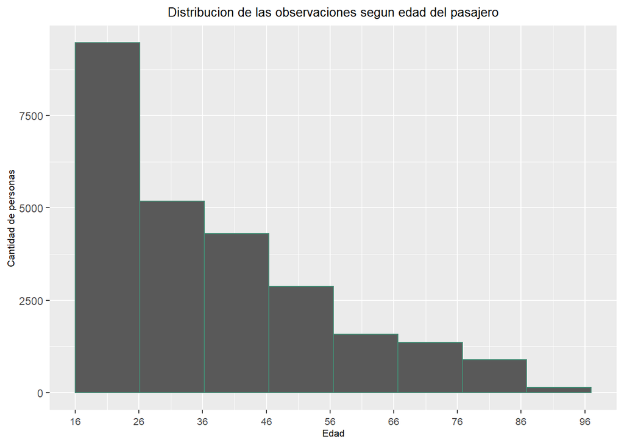

```r
ggplot(data = df) +
  geom_histogram(mapping = aes(x = ageOFocc, fill = ageOFocc),
                 bins = 9, color = "aquamarine4", boundary = 16, closed = "left") +
          labs(title = "Distribucion de las observaciones segun edad del pasajero") +
          xlab("Edad") +
          ylab("Cantidad de personas") +
          theme(plot.title = element_text(size = 10, hjust = 0.5),
                axis.text.x = element_text(size = 8, vjust = 0.5),
                axis.title = element_text(size = 8)) +
          scale_x_continuous(breaks = seq(16,96,10), labels = as.integer(seq(16,96,10)))
```

Puede verse que la mayor cantidad de accidentes ocurre en personas de entre 16 y 26 años.

Inferencia: ¿existe una diferencia relevante de edad entre las personas que mueren en accidentes de transito versus las que no mueren?

Para ello se realizara un test de hipotesis de medias diferentes entre grupos. El grafico a continuacion muestra un resumen de los principales estadisticos de la edad de los pasajeros distinguiendo entre “dead” y “alive”:

```r
summary(df %>% filter(dead == "alive") %>% .$ageOFocc)
```

```
   Min. 1st Qu.  Median    Mean 3rd Qu.    Max.
  16.00   22.00   33.00   36.86   47.00   97.00
```

```r
summary(df %>% filter(dead == "dead") %>% .$ageOFocc)
```

```
   Min. 1st Qu.  Median    Mean 3rd Qu.    Max.
  16.00   25.00   40.00   43.52   59.00   97.00
```

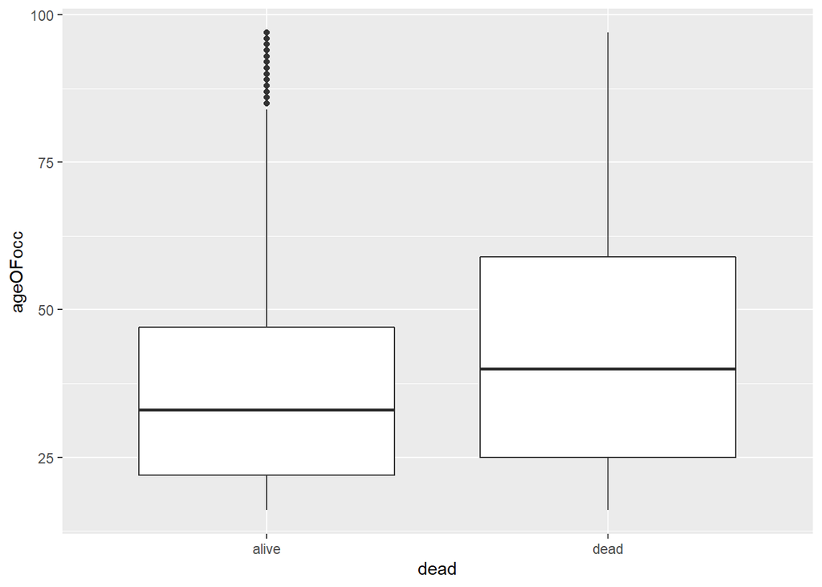

```r
ggplot(df, aes(dead, ageOFocc)) +
        geom_boxplot()
```

Del box plot parece observarse que el promedio de edad de la gente que muere es superior al de la gente que sobrevive al accidente.

Luego se analiza si los datos se distribuyen normalmente o no, para luego poder decidir que tipo de test utilizar:

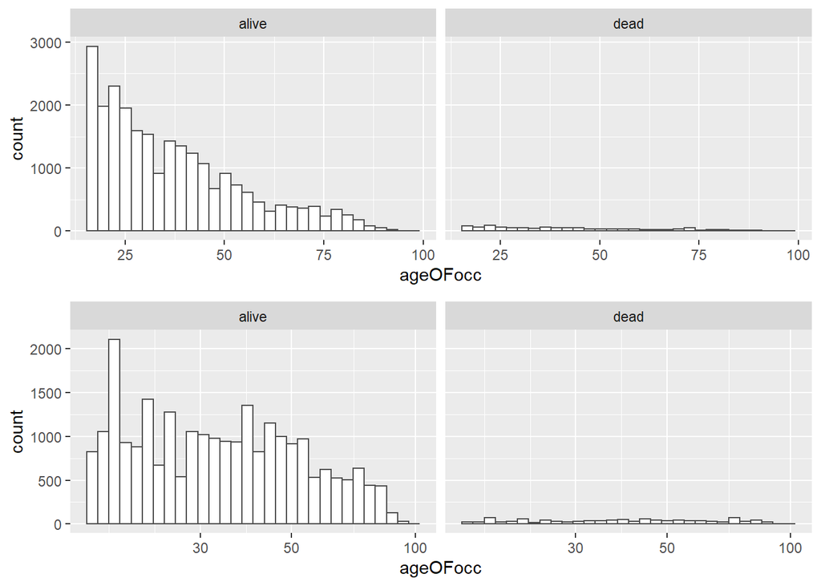

```r
#skewness
p1 <- ggplot(df, aes(ageOFocc)) +
        geom_histogram(fill = "white", color = "grey30") +
        facet_wrap(~ dead)

p2 <- ggplot(df, aes(ageOFocc)) +
        geom_histogram(fill = "white", color = "grey30") +
        facet_wrap(~ dead) +
        scale_x_log10()

grid.arrange(p1, p2, nrow = 2)
```

Los graficos indican claramente que la distribucion de los datos no es normal, por lo tanto se llevaran a cabo dos tests distintos.

El primero es el test Welch, o prueba t de varianzas desiguales. Es una prueba de dos muestras que se utiliza para probar la hipótesis de que dos poblaciones tienen medias iguales, cuando las dos muestras tienen varianzas desiguales y/o tamaños de muestra desiguales.

```r
# welch test
t.test(log(ageOFocc) ~ dead, data = df)
```

```
    Welch Two Sample t-test

data:  log(ageOFocc) by dead
t = -10.162, df = 1154.6, p-value < 2.2e-16
alternative hypothesis: true difference in means is not equal to 0
95 percent confidence interval:
 -0.1863816 -0.1260583
sample estimates:
mean in group alive  mean in group dead
           3.499241            3.655461
```

Por otro lado, el test Wilcoxon es una prueba no paramétrica que puede utilizarse para determinar si dos muestras dependientes se seleccionaron de poblaciones que tienen la misma distribución. Se utiliza cuando no se puede suponer que la distribución de la diferencia entre las medias de dos muestras esté normalmente distribuida.

```r
# wilcox test
wilcox.test(ageOFocc ~ dead, data = df)
```

```
    Wilcoxon rank sum test with continuity correction

data:  ageOFocc by dead
W = 10825058, p-value < 2.2e-16
alternative hypothesis: true location shift is not equal to 0
```

En ambos casos puede verse que ambos tests se rechazan, lo que quiere decir que efectivamente hay una diferencia estadisticamente significativa entre la media de la edad de las personas que mueren en los accidentes de transito de la muestra y la media de la edad de quienes sobreviven.

## 2.4 Estadistica descriptiva de fechas

Existen dos variables en el dataset que representan años: `yearacc` y `yearVeh`. Para analizar los datos a nivel vehiculo, es necesario eliminar una observacion en los casos en que habia dos pasajeros en el coche, para que quede una observacion por coche:

```r
df_id_veh <- df %>% distinct(case_id_vehiculo, .keep_all = TRUE)
```

### 2.4.1 `yearVeh`

```r
df_id_veh %>%
  mutate(intervalos = cut(yearVeh, breaks = 10, dig.lab = 0)) %>%
  group_by(intervalos) %>%
  dplyr::summarise(cantidad_vehiculos = n_distinct(case_id_vehiculo),
                   porcentaje = paste0(round(cantidad_vehiculos/20425*100,2),"%")) %>%
  knitr::kable(caption = "Cantidad de vehiculos segun año del modelo de coche") %>%
  column_spec (1:3, border_left = T, border_right = T) %>%
  kableExtra::row_spec(10, extra_css = "border-bottom: 1px solid") %>%
  kable_styling(font_size =  10, full_width = F)
```

Cantidad de vehiculos segun año del modelo de coche

| intervalos | cantidad_vehiculos | porcentaje |
| --- | --- | --- |
| (1953,1958] | 2 | 0.01% |
| (1958,1963] | 2 | 0.01% |
| (1963,1968] | 29 | 0.14% |
| (1968,1973] | 68 | 0.33% |
| (1973,1978] | 136 | 0.67% |
| (1978,1982] | 544 | 2.66% |
| (1982,1987] | 2671 | 13.08% |
| (1987,1992] | 5244 | 25.67% |
| (1992,1997] | 7308 | 35.78% |
| (1997,2002] | 4421 | 21.65% |

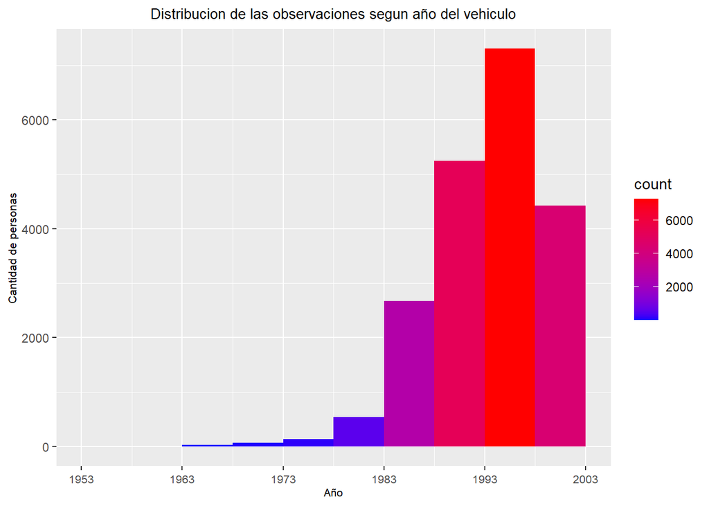

```r
hp<-qplot(x = df_id_veh$yearVeh, fill= ..count.., geom="histogram", binwidth = 5, boundary = 1953, closed = "left")
# Sequential color scheme
hp+scale_fill_gradient(low="blue", high="red")+
  labs(title = "Distribucion de las observaciones segun año del vehiculo")+
  xlab("Año") +
          ylab("Cantidad de personas") +
          theme(plot.title = element_text(size = 10, hjust = 0.5),
                axis.text.x = element_text(size = 8, vjust = 0.5),
                axis.title = element_text(size = 8)) +
          scale_x_continuous(breaks = seq(1953,2003,10), labels = as.integer(seq(1953,2003,10)))
```

Se observa que la mayor cantidad de vehiculos corresponden a modelos que han salido entre los años 1993 a 1998.

### 2.4.2 `yearacc`

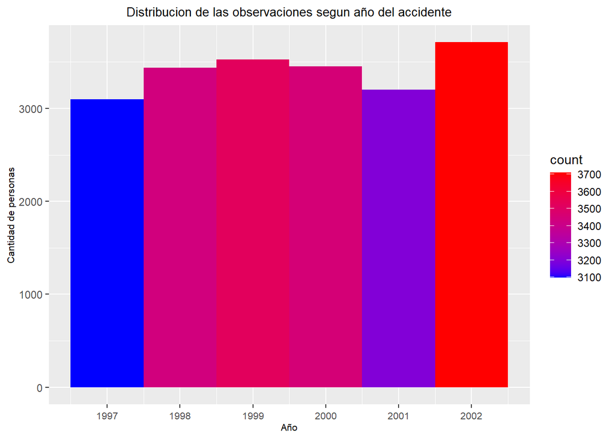

```r
hp1 <- qplot(x = df_id_veh$yearacc, fill= ..count.., geom="histogram", binwidth = 1)
hp1+scale_fill_gradient(low="blue", high="red")+
  labs(title = "Distribucion de las observaciones segun año del accidente")+
  xlab("Año") +
          ylab("Cantidad de personas") +
          theme(plot.title = element_text(size = 10, hjust = 0.5),
                axis.text.x = element_text(size = 8, vjust = 0.5),
                axis.title = element_text(size = 8)) +
          scale_x_continuous(breaks = seq(1997,2003,1), labels = as.integer(seq(1997,2003,1)))
```

Puede verse que la cantidad de accidentes esta distribuida de forma pareja entre los distintos años en los que se relevan los accidentes. El año con menor cantidad de accidentes es 1997, con 3.099 casos; en el año 2002 se registra la mayor cantidad de accidentes, que ascienden a 3.711.

## 2.5 Analisis conjunto de variables de distintos tipos

### 2.5.1 `airbag_deployed` , `speed_impact` y `dead`

Una relacion que resulta relevante para el presente trabajo es la que pueda existir entre la presencia de airbag o no, la velocidad a la que ocurrio el impacto y si el pasajero murio o no:

```r
t <- round(prop.table(table(df$dead, df$speed_impact, df$airbag_deployed), margin = c(1,3)),3)

t_nod_a <- as.data.frame(t["alive", ,])
t_nod_a$dead <- "alive"
t_nod_d <- as.data.frame(t["dead", , ])
t_nod_d$dead <- "dead"
t_nod <- rbind(t_nod_a, t_nod_d)
t_nod <- dplyr::rename(t_nod, airbag = Var2)
```

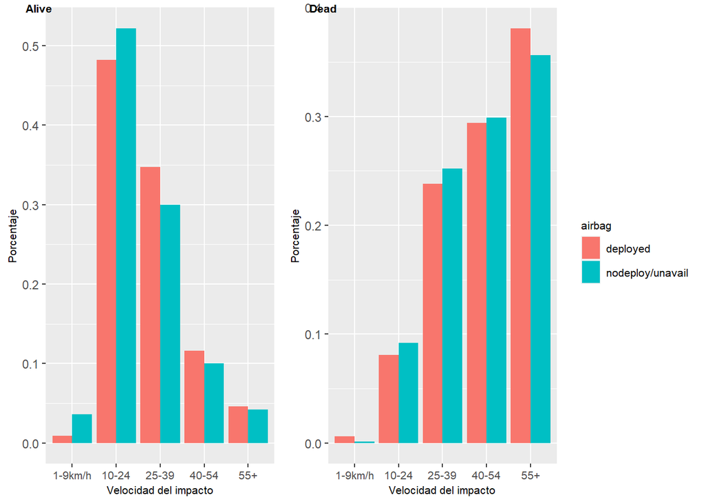

```r
p1 <- t_nod %>% filter(dead == "alive") %>%
  ggplot(mapping = aes(x= Var1, y = Freq, fill = airbag)) +
  geom_bar(position = "dodge", stat = "identity") +
   labs(y = "Porcentaje",
        x = "Velocidad del impacto") +
        theme(plot.title = element_text(size=10, hjust = 0.5),
        axis.text.x = element_text(size=8),
        axis.title = element_text(size = 8)) +
        guides(fill=FALSE, color=FALSE)

p2 <- t_nod %>% filter(dead == "dead") %>%
  ggplot(mapping = aes(x= Var1, y = Freq, fill = airbag)) +
  geom_bar(position = "dodge", stat = "identity") +
        theme(legend.title = element_text(size=8),
        legend.text = element_text(size=8)) +
   labs(y = "Porcentaje",
        x = "Velocidad del impacto") +
        theme(plot.title = element_text(size=10, hjust = 0.5),
        axis.text.x = element_text(size=8),
        axis.title = element_text(size = 8),
        legend.key.width = unit(.5,"cm"))


row <- plot_grid( p1 + theme(legend.position="none"),
           p2 + theme(legend.position="none"),
           align = 'vh',
           labels = c("Alive", "Dead"),
           hjust = -1,
           nrow = 1,
           label_size = 8
           )

legend <- get_legend(p2)
plot_grid(row, legend, rel_widths = c(2, .5), label_size = 3)
```

En el grafico anterior se han dividido los siniestros entre aquellos donde el ocupante resulta con vida, y los casos en los que fallece, desagregado por rangos de velocidad al momento del impacto.

En el primer grafico, se observa que en aquellos casos en los que el impacto ocurrio a velocidades bajas (1-9km/h y 10-24km/h), hay una mayor proporcion de supervivientes entre aquellos a quienes no se les desplego o no poseian airbag. Luego para las velocidades intermedias (25-39km/h y 40-54km/h) se releva el caso contrario, con mejores porcentajes de sobrevida entre quienes poseian y se desplego el airbag. Por ultimo, para velocidades de mas de 55km/h, no se observan marcadas diferencias entre ambos casos.

En el segundo grafico, se observa que en aquellos casos en los que el impacto ocurrio a velocidades en el rango de los 1-9 km/h y a mas de 55 km/h, hay una mayor proporcion de casos en los que el airbag se desplego, mientras que, en las tres velocidades intermedias, ocurre lo contrario.

```r
tt <- round(prop.table(table(df$dead, df$airbag_deployed, df$speed_impact), margin = c(1,3)),3)
t_nod_a1 <- as.data.frame(tt[,"deployed", ])
t_nod_a1$airbag<- "deployed"
t_nod_d1 <- as.data.frame(tt[, "nodeploy/unavail" , ])
t_nod_d1$airbag <- "nodeploy/unavail"
t_nod1 <- rbind(t_nod_a1, t_nod_d1)
t_nod1 <- dplyr::rename(t_nod1, dead = Var1)
t_nod1
```

```
    dead    Var2  Freq           airbag
1  alive 1-9km/h 0.118         deployed
2   dead 1-9km/h 0.667         deployed
3  alive   10-24 0.320         deployed
4   dead   10-24 0.274         deployed
5  alive   25-39 0.370         deployed
6   dead   25-39 0.286         deployed
7  alive   40-54 0.373         deployed
8   dead   40-54 0.295         deployed
9  alive     55+ 0.357         deployed
10  dead     55+ 0.313         deployed
11 alive 1-9km/h 0.882 nodeploy/unavail
12  dead 1-9km/h 0.333 nodeploy/unavail
13 alive   10-24 0.680 nodeploy/unavail
14  dead   10-24 0.726 nodeploy/unavail
15 alive   25-39 0.630 nodeploy/unavail
16  dead   25-39 0.714 nodeploy/unavail
17 alive   40-54 0.627 nodeploy/unavail
18  dead   40-54 0.705 nodeploy/unavail
19 alive     55+ 0.643 nodeploy/unavail
20  dead     55+ 0.687 nodeploy/unavail
```

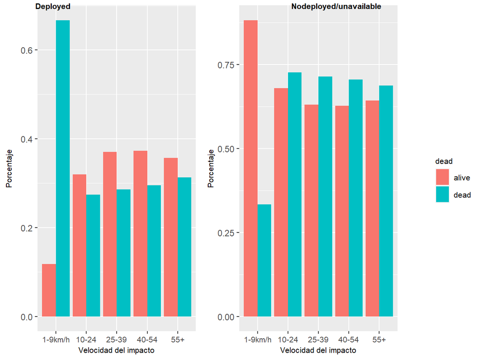

```r
p1 <- t_nod1 %>% filter(airbag == "deployed") %>%
  ggplot(mapping = aes(x= Var2, y = Freq, fill = dead)) +
  geom_bar(position = "dodge", stat = "identity") +
   labs(y = "Porcentaje",
        x = "Velocidad del impacto") +
        theme(plot.title = element_text(size=10, hjust = 0.5),
        axis.text.x = element_text(size=8),
        axis.title = element_text(size = 8)) +
        guides(fill=FALSE, color=FALSE)

p2 <- t_nod1 %>% filter(airbag == "nodeploy/unavail") %>%
  ggplot(mapping = aes(x= Var2, y = Freq, fill = dead)) +
  geom_bar(position = "dodge", stat = "identity") +
  theme(legend.title = element_text(size=8),
        legend.text = element_text(size=8)) +
   labs(y = "Porcentaje",
        x = "Velocidad del impacto") +
        theme(plot.title = element_text(size=10, hjust = 0.5),
        axis.text.x = element_text(size=8),
        axis.title = element_text(size = 8),
        legend.key.width = unit(.5,"cm"))


row <- plot_grid( p1 + theme(legend.position="none"),
           p2 + theme(legend.position="none"),
           align = 'vh',
           labels = c("Deployed", "Nodeployed/unavailable"),
           hjust = -1,
           nrow = 1,
           label_size = 8
           )

legend <- get_legend(p2)
plot_grid(row, legend, rel_widths = c(2, .5), label_size = 5)
```

A continuacion, se ha procedido a dividir los accidentes de transito entre aquellos en los que el airbag se ha desplegado y los que no poseian o no se desplego, desagregado por rangos de velocidad.

En el primer grafico, se pone de manifiesto que en aquellos casos en los que se desplego el airbag, existe una proporcion notable de mortalidad a velocidades bajas. Dicha tendencia se revierte para los demas rangos de velocidad, siendo mayor la proporcion de sobrevivientes con respecto a la de fallecidos.

En el segundo grafico se ve que entre aquellos a quienes no se les ha desplegado o no poseían airbag, contrariamente a los señalado anteriormente, el porcentaje de sobrevivientes es muy superior a bajas velocidades. Esta tendencia se revierte para los otros rangos, siendo mayor la proporcion de fallecidos que de supervivientes.

# 3 Parte tercera: Aprendizaje estadistico

## 3.1 Pre-procesado de datos

Se elimina la variable `airbag`, puesto que la informacion que brinda ya esta contenida en `airbag_deployed`, y la varaible `injSeverity`, para evitar multicolinealidad con `dead`. Tambien se quitan las dos columnas de identificacion :

```r
df1 <- dplyr::select(df, -injSeverity, -airbag, -case_id_vehiculo, - case_id_persona, - caseid)
```

### 3.1.1 Datos categoricos

Se etiquetan los datos categoricos para su representacion numerica:

```r
df1$speed_impact = ordered(df1$speed_impact,
                levels = c("1-9km/h", "10-24", "25-39", "40-54", "55+"),
                labels = c(1,2,3,4,5))

df1$dead = factor(df1$dead,
                levels = c("alive", "dead"),
                labels = c(0,1))

df1$seatbelt = factor(df1$seatbelt,
                levels = c("belted", "none"),
                labels = c(1,0))

df1$female = factor(df1$female,
                levels = c("f", "m"),
                labels = c(1,0))

df1$airbag_deployed = factor(df1$airbag_deployed,
                levels = c("nodeploy/unavail", "deployed"),
                labels = c(0,1))

df1$occRole = factor(df1$occRole)

df1$frontal = factor(df1$frontal)
```

### 3.1.2 Analisis de correlacion entre variables

En primer lugar, se evalua la correlacion entre todas las variables:

```r
hetcor(df1)
```

```
Two-Step Estimates

Correlations/Type of Correlation:
                speed_impact       dead   seatbelt    frontal     female
speed_impact               1 Polychoric Polychoric Polychoric Polychoric
dead                  0.5826          1 Polychoric Polychoric Polychoric
seatbelt              0.2648     0.3493          1 Polychoric Polychoric
frontal               0.1377    -0.1859     0.1104          1 Polychoric
female                0.1013    0.08337     0.1988     0.1008          1
ageOFocc            -0.05768     0.1484    -0.1094   -0.05887   -0.06161
yearacc             -0.04127   -0.04798   -0.04848    0.02035  -0.005133
yearVeh              -0.1386    -0.1134    -0.2263   -0.03644    -0.1252
airbag_deployed      0.09309   -0.04909    -0.1055     0.3867   -0.05948
occRole             -0.01075     0.0442     0.1219   -0.05935    -0.1819
                  ageOFocc    yearacc    yearVeh airbag_deployed    occRole
speed_impact    Polyserial Polyserial Polyserial      Polychoric Polychoric
dead            Polyserial Polyserial Polyserial      Polychoric Polychoric
seatbelt        Polyserial Polyserial Polyserial      Polychoric Polychoric
frontal         Polyserial Polyserial Polyserial      Polychoric Polychoric
female          Polyserial Polyserial Polyserial      Polychoric Polychoric
ageOFocc                 1    Pearson    Pearson      Polyserial Polyserial
yearacc          -0.006566          1    Pearson      Polyserial Polyserial
yearVeh            0.01956     0.2967          1      Polyserial Polyserial
airbag_deployed   0.009389     0.1581     0.7047               1 Polychoric
occRole           -0.08377  -0.005232   -0.01864         -0.1611          1

Standard Errors:
                speed_impact    dead seatbelt  frontal   female ageOFocc
speed_impact
dead                 0.01111
seatbelt            0.008435 0.01615
frontal             0.008584 0.01719  0.01056
female              0.008454 0.01754  0.01009 0.009964
ageOFocc            0.006783 0.01257 0.008328 0.007909 0.007772
yearacc             0.006779 0.01391 0.008234 0.008001 0.007815 0.006228
yearVeh             0.006595 0.01299 0.007602 0.008046 0.007763 0.006226
airbag_deployed     0.008793 0.01825  0.01066 0.009405  0.01009 0.008062
occRole             0.009601  0.0194  0.01141  0.01123  0.01076 0.008768
                 yearacc  yearVeh airbag_deployed
speed_impact
```

[output cut: 20 more lines]

```
yearacc                    0          0          0          0          0
yearVeh                    0 8.235e-269 1.894e-298 9.351e-272 1.254e-276
airbag_deployed    3.003e-25       <NA>       <NA>       <NA>       <NA>
occRole               0.3393       <NA>       <NA>       <NA>       <NA>
                             ageOFocc yearacc    yearVeh airbag_deployed
speed_impact
dead
seatbelt
frontal
female
ageOFocc
yearacc                             0
yearVeh                             0       0
airbag_deployed             8.24e-281       0          0
occRole         2.60500000017023e-314       0 2.362e-269            <NA>
```

Existe un solo par de variables que tienen un nivel de correlacion alto, de 0.7047, entre airbag_deployed y el año del coche. Esto tiene sentido, pues seguramente los coches mas antiguos no contienen airbag. En este sentido, en EEUU, el uso de airbags se volvio obligatorio a partir del 1 de septiembre de 1998, en los dos asientos delanteros del coche. Por tanto, puede esperarse que no todos los coches anteriores a 1998 tengan airbag.

En conclusion, para evitar problemas de multicolinealidad se elimina la variable `yearVeh`:

```r
df1 <- dplyr::select(df1, -yearVeh)
```

### 3.1.3 Division de los datos en train y test

Con ayuda del paquete `caret`, se dividen los datos de la siguiente manera:

- 60% train
- 20% validation
- 20% test

```r
set.seed(111)

inTraining <- createDataPartition(df1$dead, p=0.6, list=FALSE)
training.set <- df1[inTraining,]
Totalvalidation.set <- df1[-inTraining,]
inValidation <- createDataPartition(Totalvalidation.set$dead, p=0.5, list=FALSE)
testing.set <- Totalvalidation.set[inValidation,]
validation.set <- Totalvalidation.set[-inValidation,]

dataset <- training.set
validation <- validation.set
test <- testing.set
total <- rbind(dataset, validation) # training + validation
```

## 3.2 Aplicacion de modelos

### 3.2.1 Regresión lineal para variable continua: `ageOFocc`

A continuacion se realiza una regresion lineal, en donde se busca estimar la edad de las personas que han formado parte de algun accidente de transito, en funcion de todas las demas variables del dataset.

```r
lm <- train(ageOFocc ~ ., data = total, method = "lm")
#summary_lm = summary(lm)
#saveRDS(summary_lm, "summary_lm.csv")
#summary_lm = readRDS("summary_lm.csv")
summary(lm)
```

```
Call:
lm(formula = .outcome ~ ., data = dat)

Residuals:
    Min      1Q  Median      3Q     Max
-31.936 -14.245  -4.176  10.336  69.273

Coefficients:
                  Estimate Std. Error t value Pr(>|t|)
(Intercept)      215.98146  145.18463   1.488   0.1369
speed_impact.L    -3.38129    0.62000  -5.454 4.99e-08 ***
speed_impact.Q    -3.08058    0.52329  -5.887 4.00e-09 ***
speed_impact.C     0.66979    0.38829   1.725   0.0845 .
`speed_impact^4`  -0.31923    0.27183  -1.174   0.2403
dead1              9.66079    0.65216  14.814  < 2e-16 ***
seatbelt0         -2.84091    0.27993 -10.149  < 2e-16 ***
frontal1          -1.16672    0.26700  -4.370 1.25e-05 ***
female0           -1.47353    0.24977  -5.899 3.70e-09 ***
yearacc           -0.08896    0.07261  -1.225   0.2206
airbag_deployed1   0.37238    0.27162   1.371   0.1704
occRole1          -2.71842    0.30472  -8.921  < 2e-16 ***
---
Signif. codes:  0 '***' 0.001 '**' 0.01 '*' 0.05 '.' 0.1 ' ' 1

Residual standard error: 17.6 on 20610 degrees of freedom
Multiple R-squared:  0.02734,   Adjusted R-squared:  0.02682
F-statistic: 52.66 on 11 and 20610 DF,  p-value: < 2.2e-16
```

En primer lugar, se aclara el nombre de cada una de las variables que el algoritmo genera a partir del factor ordenado `speed_impact`:

- speed_impact.L : L = Linear, equivale al primer nivel de la variable, es decir, una velocidad de impacto de 1-9 km/h
- speed_impact.C : C = Cuadratic, equivale al segundo nivel de la variable, es decir, una velocidad de impacto de 10-24 km/h
- speed_impact.Q : Q = Qubic, equivale al tercer nivel de la variable, es decir, una velocidad de impacto de 25-39 km/h
- speed_impact^4`: equivale al cuarto nivel de la variable, es decir, una velocidad de impacto de 40-54 km/h
- grupo de control, que no figura en la regresion, es el nivel de mas de 55 km/h.

El alogoritmo detecta 7 variables estadisticamente muy significativas. Las primeras dos variables hacen referencia a la velocidad de impacto.

Anlizando la performance de la regresion, puede decirse que es muy mala: el R cuadrado es muy bajo, apenas del 0.027. Esto quizas se debe a que la regresion es un tanto forzada, pues el conjunto de datos apunta a echar luz sobre el efecto del uso de airbags en la tasa de fatalidad de los accidentes de transito.

Algunas variables resultan interesantes de analizar en este caso. Por ejemplo `seatbelt0`: esta indica que las personas que no usan cinturon de seguridad tienen en promedio menos edad que aquellas que si usan en cinturon de seguridad.

Otra variable es `frontal1`: en promedio, la edad promedio de las personas que participan de choques frontales es menor que la edad de las personas involucradas en choques laterales.

### 3.2.2 Regresion logistica para clasificar una variable discreta: `dead`

```r
#glm <- glm(dead ~ ., data = total, family = binomial)
#saveRDS(glm, "glm.csv")
glm = readRDS("glm.csv")
summary(glm, vcov = sandwich, df = Inf, diagnostics = T)
```

```
Call:
glm(formula = dead ~ ., family = binomial, data = total)

Deviance Residuals:
    Min       1Q   Median       3Q      Max
-1.8250  -0.2413  -0.1348  -0.0873   3.5175

Coefficients:
                  Estimate Std. Error z value Pr(>|z|)
(Intercept)      33.607020  45.599153   0.737  0.46112
speed_impact.L    4.400461   0.637118   6.907 4.96e-12 ***
speed_impact.Q   -0.164477   0.539072  -0.305  0.76028
speed_impact.C   -0.033561   0.328282  -0.102  0.91857
speed_impact^4   -0.003663   0.144990  -0.025  0.97985
seatbelt0         1.082677   0.079820  13.564  < 2e-16 ***
frontal1         -1.143048   0.080534 -14.193  < 2e-16 ***
female0           0.100449   0.080105   1.254  0.20985
ageOFocc          0.030975   0.002024  15.302  < 2e-16 ***
yearacc          -0.019165   0.022806  -0.840  0.40071
airbag_deployed1 -0.007234   0.085803  -0.084  0.93281
occRole1          0.240852   0.091116   2.643  0.00821 **
---
Signif. codes:  0 '***' 0.001 '**' 0.01 '*' 0.05 '.' 0.1 ' ' 1

(Dispersion parameter for binomial family taken to be 1)

    Null deviance: 7135.8  on 20621  degrees of freedom
Residual deviance: 5201.8  on 20610  degrees of freedom
AIC: 5225.8

Number of Fisher Scoring iterations: 8
```

```r
glm.probs = predict(glm, newdata = test, type = "response")
glm.pred = as.factor(ifelse(glm.probs>0.5,1,0))
dead.test = test$dead
conf_matrix_glm <- confusionMatrix(glm.pred, dead.test, mode = "prec_recall", positive = "1")
conf_matrix_glm
```

```
Confusion Matrix and Statistics

          Reference
Prediction    0    1
         0 4924  193
         1   17   22

               Accuracy : 0.9593
                 95% CI : (0.9535, 0.9645)
    No Information Rate : 0.9583
    P-Value [Acc > NIR] : 0.3806

                  Kappa : 0.1625

 Mcnemar's Test P-Value : <2e-16

              Precision : 0.564103
                 Recall : 0.102326
                     F1 : 0.173228
             Prevalence : 0.041699
         Detection Rate : 0.004267
   Detection Prevalence : 0.007564
      Balanced Accuracy : 0.549442

       'Positive' Class : 1
```

En primer lugar puede verse que la regresión logística tiene una muy buena accuracy: 0.9593, es decir, se ha predicho correctamente el 96% de las obervaciones de la muestra. Sin embargo, esta metrica no permite distinguir si los casos positivos han sido correctamente predichos.

Para ello, se puede analizar la True Positive Rate o el recall = TP / TP + FN: da visibilidad de la perfomance del clasificador en cuanto aquellos casos positivos que han sido correctamente clasificados. Dado que en en esta aplicacion en particular los casos positivos se refieren a personas que han muerto en un accidente de transito, resulta central poder detectar estos casos. Un recall de 0.1023 es muy bajo, solo el 10% de los casos positivos han sido detectados por el algoritmo.

En cuanto a la interpretacion de los coeficientes estimados por el modelo, solo cinco variables son estadisticamente significativas:

ageOFocc: un año mas de edad del ocupante incrementa las muertes en un 3%

occRole1: las muertes aumentan un 24% cuando el conductor viaja solo en comparacion a cuando viaja acompañado.

### 3.2.3 Reduccion de la dimensionalidad mediante PCA

A continuacion se reduce la dimensionalidad del dataset, de 9 variables a tan solo dos, mediante una tecnica de aprendizaje no supervisado “Principal Components Analysis”:

```r
# escalado de valores
total_esc <- total
test_esc <- test
total_esc[, 6:7] <- scale(total_esc[, 6:7])
test_esc[, 6:7] <- scale(test_esc[, 6:7])

# proyeccion de los componentes principales

pca <- preProcess(x = total_esc[, -2], method = "pca", pcaComp = 2)
total_esc_pca <- total_esc
total_esc_pca <- predict(pca, total_esc_pca)
total_esc_pca <- dplyr::select(total_esc_pca, 8,9, 2)

test_esc_pca <- test_esc
test_esc_pca = predict(pca, test_esc_pca)
test_esc_pca <- dplyr::select(test_esc_pca, 8,9, 2)
```

Una vez que se ha reducido la dimensionalidad, se utiliza el output de este algoritmo como input del clustering jerarquico que sigue a continuacion.

### 3.2.4 Clustering Jerarquico

Se aplica un clustering jerarquico con el conjunto de datos reducidos a dos dimensiones:

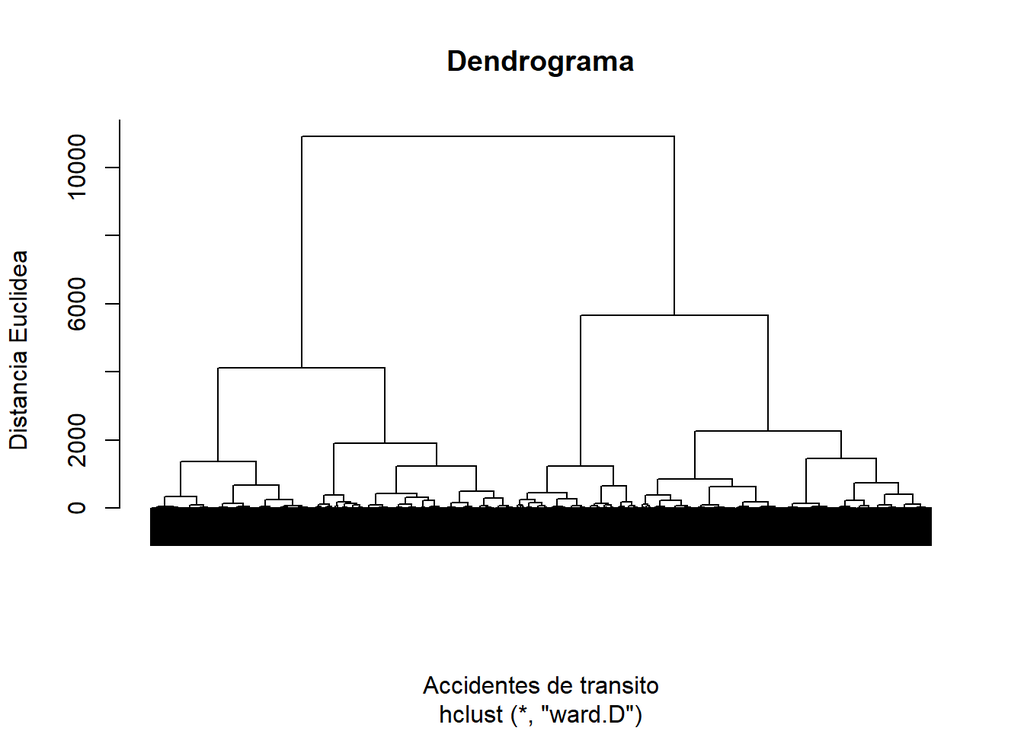

```r
test_train <- rbind(total_esc_pca, test_esc_pca)

dendrogram <- hclust(dist(test_train, method = "euclidean"), method = "ward.D")
plot(dendrogram,
     main = "Dendrograma",
     xlab = "Accidentes de transito",
     ylab = "Distancia Euclidea",
     labels=FALSE)
```

Del grafico anterior hay que deducir la cantidad de clusters optimos a seleccionar. Puede verse que la linea vertical mas alta que no es atravesada horizontalmente por otra linea señala que alli debe hacerse el corte, y que el resultado es que deben agruparse los datos en 4 grupos:

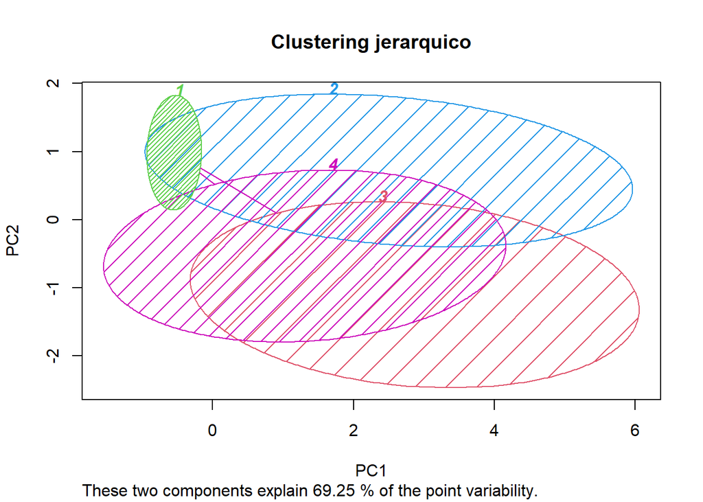

```r
#hc <- hclust(dist(test_train, method = "euclidean"), method = "ward.D")
#saveRDS(hc, "hc.csv")
hc = readRDS("hc.csv")

y_hc <- cutree(hc, k = 4) # prediccion

clusplot(test_train,
          y_hc,
          lines = 2,
          shade = TRUE,
          color = TRUE,
          labels = 4,
          plotchar = FALSE,
          span = TRUE,
          main = "Clustering jerarquico",
          xlab = "PC1",
          ylab = "PC2",
         cex = 0)
```

### 3.2.5 Gradient Boosting

```r
set.seed(123)
fitControl <- trainControl(method = 'cv', number = 10, summaryFunction=defaultSummary)

# parametros a ajustar de gradient boosting:

getModelInfo()$gbm$parameters
```

```
          parameter   class                   label
1           n.trees numeric   # Boosting Iterations
2 interaction.depth numeric          Max Tree Depth
3         shrinkage numeric               Shrinkage
4    n.minobsinnode numeric Min. Terminal Node Size
```

```r
gbmGrid <-  expand.grid(interaction.depth = c(1,4,7,10),
                        n.trees = c(500,1000,2000),
                        shrinkage = c(.005, .02,.05),
                        n.minobsinnode = c(10,20,30))
```

```r
# set.seed(111)
# fit.gbm <- train(dead~., data = dataset, method = 'gbm', trControl = fitControl, tuneGrid = gbmGrid, metric = 'Accuracy', distribution = "bernoulli")
# #saveRDS(fit.gbm, "fit.gbm.csv")
# #fit.gbm <- readRDS("fit.gbm.csv")
# plot(fit.gbm)
# fit.gbm$bestTune
#
# res_gbm <- fit.gbm$results
# acc_gbm <- subset(res_gbm[5])
# max(acc_gbm) # CV con mejor "tune"
#
# boost.caret.pred <- predict(fit.gbm,validation)
#
# conf_matrix_gbm <- confusionMatrix(boost.caret.pred, validation$dead, mode = "prec_recall",  positive = "1")
# conf_matrix_gbm
# summary(fit.gbm)
```